# The Diagramming Dictionary_A Complete Reference Tool for Young Writers, Aspiring Rhetoricians, and Anyone Else Who Needs to Understand How English Works.Otto2019

The best place for the treasure is under the bed.

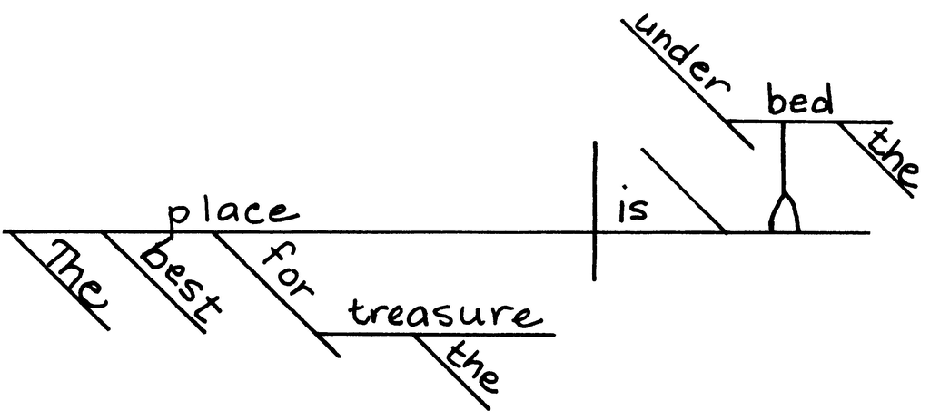

**4. 作介词宾语的介词短语：**有时介词短语作介词宾语。它在图示中被放置在水平线上的基座上，就像介词宾语通常放置的位置一样。

**4. Prepositional phrases that act as objects of the preposition:** Sometimes a prepositional phrase acts as an object of the preposition. It is diagrammed on a pedestal on the horizontal line where the object of the preposition is normally placed.

他 从树后走了出来。

He stepped from behind the tree.

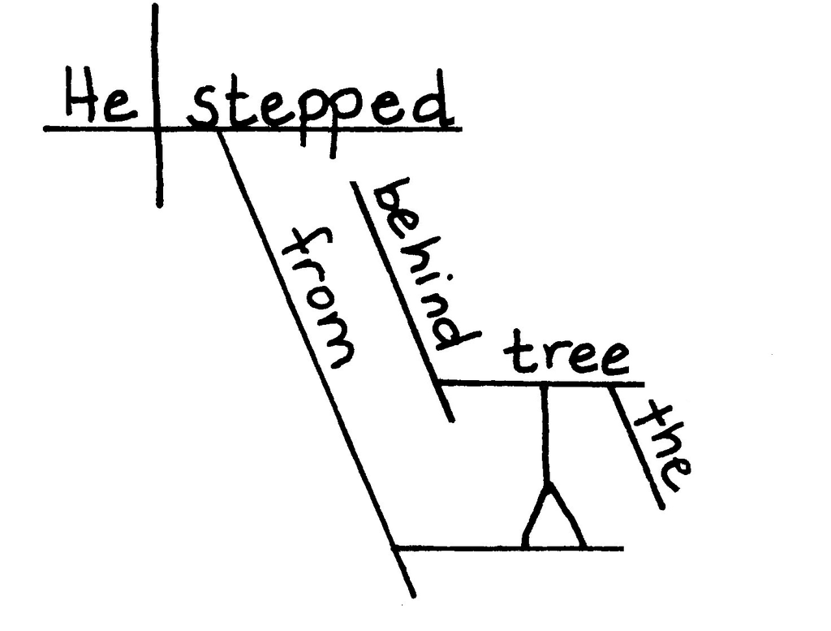

IIIC. 介词宾语，特殊情况

IIIC. Objects of prepositions, special cases

**1. 介词的复合宾语：**一个介词短语可能包含多个介词宾语。在这种情况下，这些宾语是复合的，其结构式与其他复合成分一样。宾语线用括号括起来，每个宾语写在单独的水平线上，连接它们的连词写在虚线上。

**1. Compound objects of prepositions:** A prepositional phrase may contain more than one object of the preposition. In this case, the objects are compound, and are diagrammed as any other compound element. The objects line is split into a bracket, the objects are written on separate horizontal lines, and the conjunction joining them is placed on the dotted line.

土豆奶酪焗菜 闻起来真是太香了。

The gratin of potato and cheese smelled absolutely delightful.

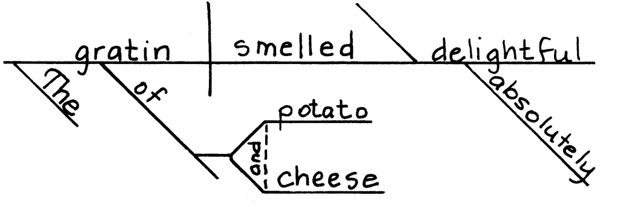

**2. 动名词作介词宾语：**动名词可以作介词宾语。在这种情况下，动名词在图示中位于水平宾语线上，但为了表明它是名词和动词的组合，它被放置在基座上并用曲线书写。

**2. Gerunds as objects of prepositions:** A gerund can function as the object of the preposition. In this case, the gerund is diagrammed on the horizontal object line, but it is placed on a pedestal and written on a curved line, in order to demonstrate that it is a combination of both noun and verb.

巨人厌倦了工作。†

The Giant was tired of working.†

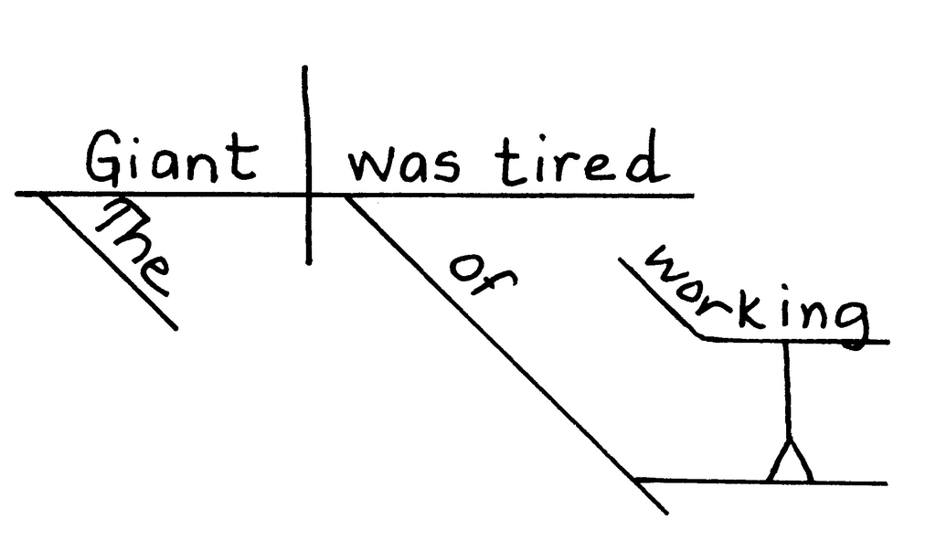

*摘自鲁德亚德·吉卜林的*《丛林之书》*

* from *The Jungle Book* by Rudyard Kipling

†改编自H.A. Guerber所著*《埃达与萨迦中的北欧神话》*

† adapted from *Myths of the Norsemen from the Eddas and Sagas* by H. A. Guerber

第四部分：物体

PART IV: OBJECTS

IVA。直接宾语

IVA. Direct objects

**1. 直接宾语：**通常，直接宾语是接受动词动作的名词或代词。它在动词之后的水平线上表示，并在动词和宾语之间画一条竖线。但是，这条竖线止于水平线，并不穿过水平线（这使得直接宾语线与主谓分界线区分开来）。

**1. Direct objects:** Usually, a direct object is a noun or pronoun receiving the action of the verb. It is diagrammed on the horizontal line after the action verb, and a vertical line is placed between the verb and the object. However, the vertical line stops at the horizontal line and does not go through (this differentiates the direct object line from the subject/verb dividing line).

我们 烤了 棉花糖。

We roasted marshmallows.

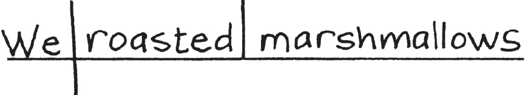

**2. 并列直接宾语：**当一个句子包含多个直接宾语时，宾语的表示方法与其他并列成分相同。水平线被分成括号，每个宾语分别放在单独的水平线上，并用虚线连接。在括号前的水平线上放置一条垂直的直接宾语线，以表明这些并列成分是直接宾语。

**2. Compound direct objects:** When a sentence contains more than one direct object, the objects are diagrammed like any other compound element. The horizontal line is split into a bracket, and the objects are each placed on separate horizontal lines with a dotted line joining them. The vertical direct object line is placed on the horizontal line before the bracket, in order to indicate that the compound elements are direct objects.

我们 烤了软棉花糖和牛肉热狗。

We roasted soft marshmallows and beefy hot dogs.

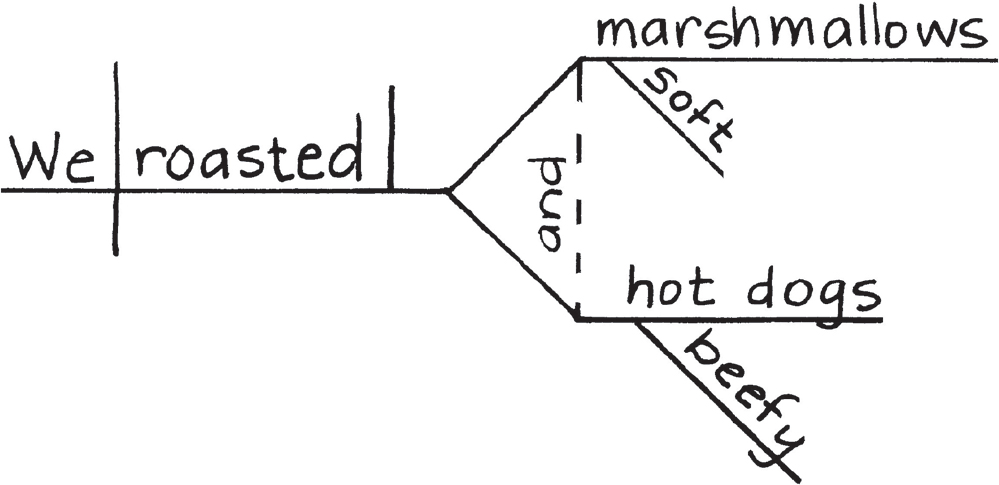

**3. 复合谓语与复合直接宾语：**当一个句子包含多个动词，并且每个动词都有自己的直接宾语时，动词放在括号中表示复合成分，直接宾语放在它们所承受动作的动词之后。

**3. Compound predicates with compound direct objects:** When a sentence contains more than one verb, and each verb has its own direct object(s), the verbs are placed on a bracket to indicate a compound element, and the direct objects are put after the verb(s) whose action they are receiving.

龙王和他的随从陪同勇士走到桥的尽头，向他鞠躬道别，并送上美好的祝愿。

The Dragon King with his retainers accompanied the warrior to the end of the bridge, and took leave of him with many bows and good wishes.

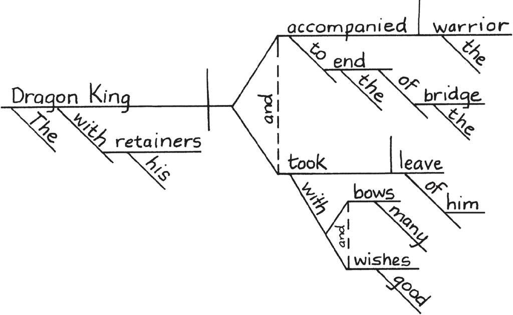

**4. 复合谓语，且宾语相同：**当一个句子包含多个动词，且这些动词共用同一个宾语时，动词用括号括起来，表示复合成分。然后将括号合拢，在横线上画一条宾语线，宾语放在动词之后。

**4. Compound predicates with the same direct object:** When a sentence contains more than one verb, and the verbs share the same direct object, the verbs are placed on a bracket to indicate a compound element. The brackets then rejoin, a direct object line is placed on the horizontal line, and the direct object goes after the verbs.

在面包店里，我 看到了我最喜欢的东西，闻到了我最喜欢的香味。

In the bakery, I see and smell my favorite things.

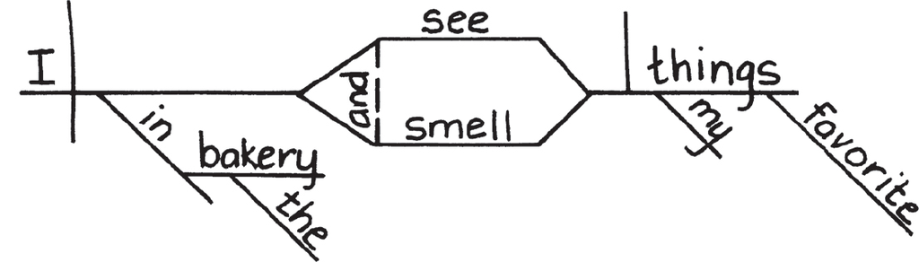

**5. 疑问代词作直接宾语：**疑问代词可以在句子中用作直接宾语。它们的结构图与普通直接宾语的结构图相同。

**5. Interrogative pronouns as direct objects:** Interrogative pronouns can be used as direct objects in a sentence. They are diagrammed just as regular direct objects would be.

他 做了 什么？

He did what?

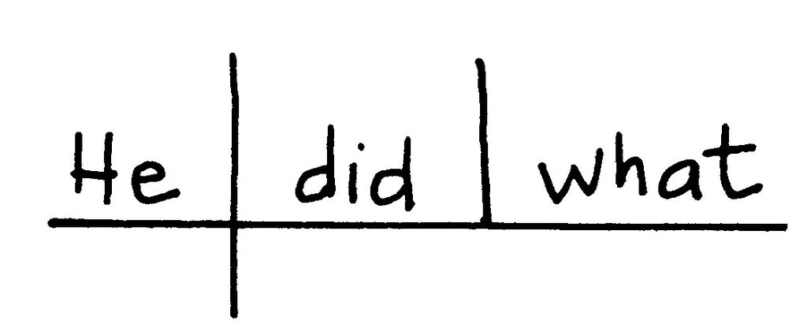

**6. 指示代词作直接宾语：**指示代词（*this*、*that*、*these*、*those*）可以作直接宾语，其结构图与普通直接宾语的结构图相同。

**6. Demonstrative pronouns as direct objects:** Demonstrative pronouns (*this*, *that*, *these*, *those*) can be direct objects and are diagrammed just as regular direct objects would be.

这是谁带来的 ？

Who brought this?

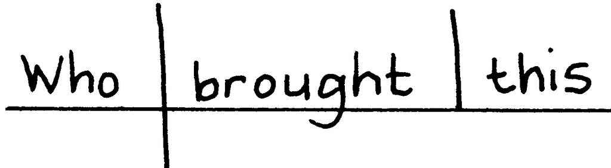

**7. 动名词作直接宾语：**当动名词作直接宾语时，它被放置在水平直接宾语线上的一个基座上。它所在的线是弯曲的，以表明动名词既是名词又是动词。

**7. Gerunds as direct objects:** When a gerund is a direct object, it is placed on a pedestal on the horizontal direct object line. The line it is on is curved to demonstrate that the gerund is part noun and part verb.

洛基 听到了 翅膀拍打的<sup>声音</sup>。

Loki heard flapping.*

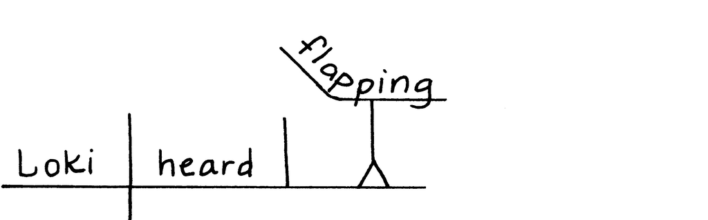

**8. 不定式作直接宾语：**当不定式作直接宾语时，它被放置在水平线上的一个基座上，位于垂直直接宾语线之后。它的线条是弯曲的，以表明该不定式既是名词又是动词。

**8. Infinitives as direct objects:** When an infinitive is a direct object, it is placed on a pedestal on the horizontal line and after the vertical direct object line. Its line is curved to demonstrate that the infinitive is part noun and part verb.

这位老兵 并不惧怕死亡。

The old soldier did not fear to die.

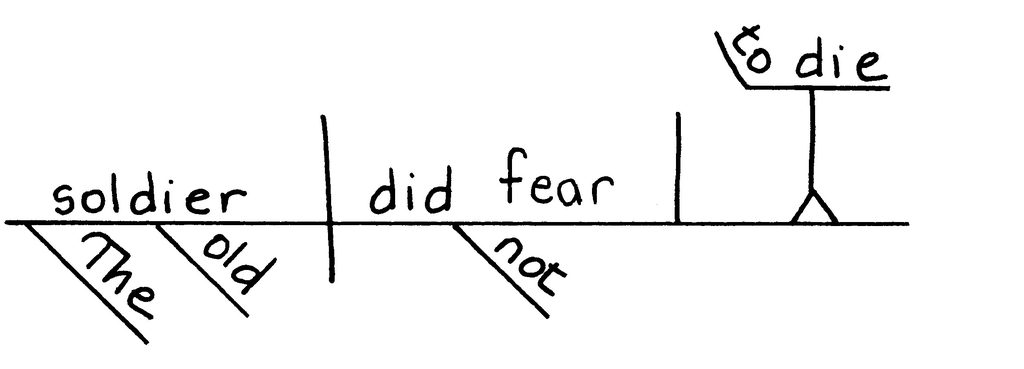

**9. 复合名词或专有名词作直接宾语：**当复合名词或专有名词用作直接宾语时，词与词之间不分开。整个名词或名称都放在直接宾语行上。

**9. Compound nouns or proper names as direct objects:** When a compound noun or proper name is used as a direct object, the words are not split up. The entire noun or name is placed on the direct object line.

美国第三任总统托马斯· 杰斐逊创建了弗吉尼亚大学。

Thomas Jefferson, who was the third President of the United States, built the University of Virginia.

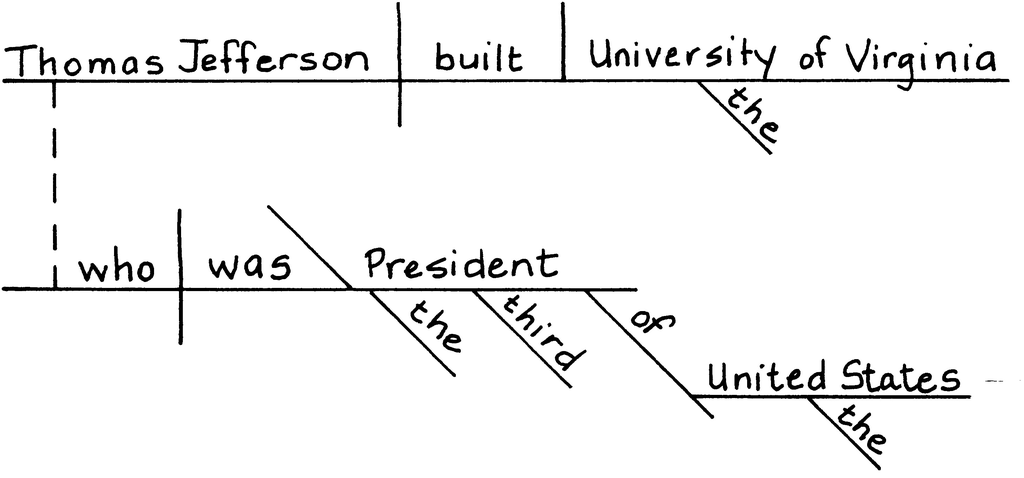

**10. 不言自明的直接宾语：**当一个句子包含一个不言自明的直接宾语（例如不言自明的关系代词）时，在图表的直接宾语位置放置一个*x 。*

**10. Understood direct object:** When a sentence contains an understood direct object (such as an understood relative pronoun), an *x* is placed in the direct object location of the diagram.

这 是杰克 建造的房子。（ x 代表*隐含*的关系代词*）*。

This is the house Jack built. (The understood relative pronoun *that* is represented by the *x* ).

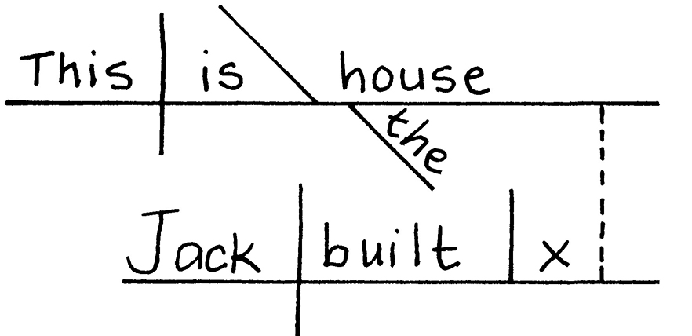

**11. 直接宾语后的同位语名词：**当一个同位语名词重新命名或解释一个直接宾语时，它被放在图表中直接宾语后面的括号中。

**11. Appositive nouns after direct objects:** When an appositive noun renames or explains a direct object, it is placed in parentheses after the direct object on the diagram.

他们 惊恐地听到越来越近的战鼓声，那是末日降临的声音。

They heard with terror the advancing drums, the sound of doom.

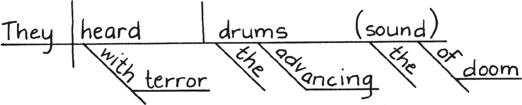

**12. 宾语补语：**当一个名词跟在直接宾语之后并对其进行重新命名时，它就是宾语补语名词。在结构式中，它位于直接宾语之后的一条水平线上，并在直接宾语和宾语补语之间画一条斜线，以表示补语是对宾语的重新命名。

**12. Object complements:** When a noun follows the direct object and renames it, it is an object complement noun. It is diagrammed on a horizontal line after the direct object, and a slanted line is placed between the direct object and the object complement to indicate that the complement is renaming the object.

该团体 选举你为主席。

The group elected you president.

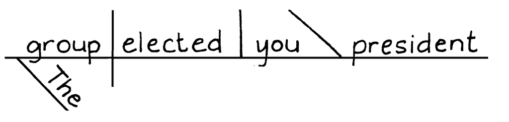

当形容词跟在直接宾语后面并描述该宾语时，它被称为宾语补语形容词，其结构图也相同。

When an adjective follows the direct object and describes that object, it is called an object complement adjective and is diagrammed the same way.

老师认为这些学生很 聪明。

The instructor found the students intelligent.

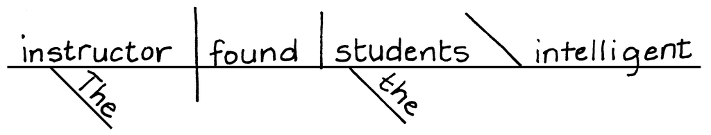

间接宾语

IVB. Indirect objects

**1. 间接宾语：**间接宾语写在动词下方的一条水平线上。它通过一条斜线与动词连接，但斜线上不写任何内容。这条斜线提醒读者，动词间接地影响间接宾语。

**1. Indirect objects:** The indirect object is written underneath the verb on a horizontal line. It connects to the verb by a slanted line, but nothing is written on the slanted line. That slanted line is a reminder that the verb indirectly affects the indirect object.

奥德修斯 问了陌生人一个问题。†

Odysseus asked the stranger a question.†

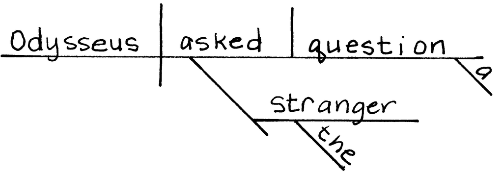

**2. 并列间接宾语：**当句子包含并列间接宾语时，两个间接宾语都放在用括号括起来的水平线上。连词放在虚线上，整个结构通过动词下方的斜线与句子连接起来。

**2. Compound indirect objects:** When a sentence contains a compound indirect object, both indirect objects are placed on horizontal lines drawn as a bracket. The conjunction is placed on the dotted line, and the entire structure is joined to the sentence on a slanted line attached underneath the verb.

布兰登 给他的表弟和叔叔发了一封电子邮件。

Brandon sent his cousin and uncle an email.

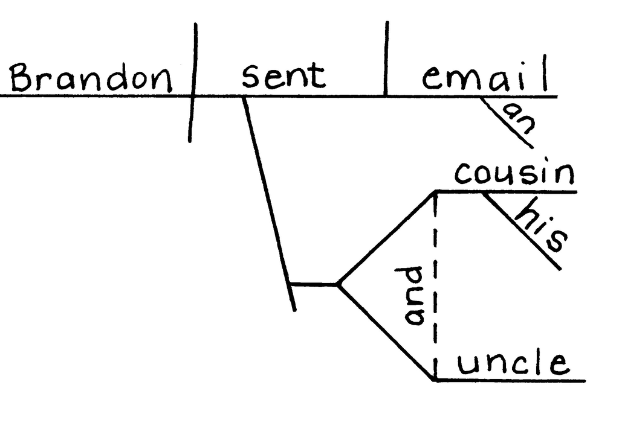

**3. 专有名词作间接宾语：**当专有名词（例如姓名或头衔）用作间接宾语时，整个名词都放在间接宾语行上。专有名词的任何部分都不能用作修饰语。

**3. Proper nouns as indirect objects:** When a proper noun such as a name or title is used as an indirect object, the entire noun is placed on the indirect object line. No part of the proper noun is used as a modifier.

我给 朱迪阿姨织了 副手套。

I knitted Aunt Judy the mittens.

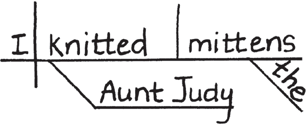

*改编自H.A. Guerber所著*《埃达与萨迦中的北欧神话》*

* adapted from *Myths of the Norsemen from the Eddas and Sagas* by H.A. Guerber

†出自荷马*史诗《奥德赛》*

† from *The Odyssey* by Homer

第五部分：表语形容词和表语主语

PART V: PREDICATE ADJECTIVES AND PREDICATE NOMINATIVES

VA. 表语形容词

VA. Predicate adjectives

**1. 表语形容词：**表语形容词在结构式中被放置在系动词后面的水平线上。在动词和表语形容词之间画一条斜线，指向主语，以此来表示表语形容词的功能（修饰主语的词）。

**1. Predicate adjective:** A predicate adjective is diagrammed by placing it on the horizontal line after the linking verb. Between the verb and the predicate adjective, a slanted line is drawn that points back to the subject, demonstrating the function of the predicate adjective (a word modifying the subject).

我 不太 受欢迎。

I am unpopular.

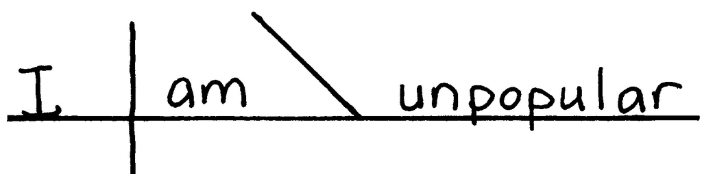

**2. 复合表语形容词：**当一个句子包含多个表语形容词时，水平表语线在系动词之后和指向主语的斜线之后分别用括号分隔。每个形容词单独放在一条水平线上，连接形容词的连词画在括号的虚线上。

**2. Compound predicate adjectives:** When a sentence contains more than one predicate adjective, the horizontal predicate line is divided into a bracket after the linking verb and after the slanted line pointing back to the subject. Each adjective is placed on a separate horizontal line, and the conjunction joining the adjectives is drawn on the dotted line of the bracket.

蝙蝠洞可能阴暗潮湿，令人毛骨悚然 。

Bat caves can be dark and creepy.

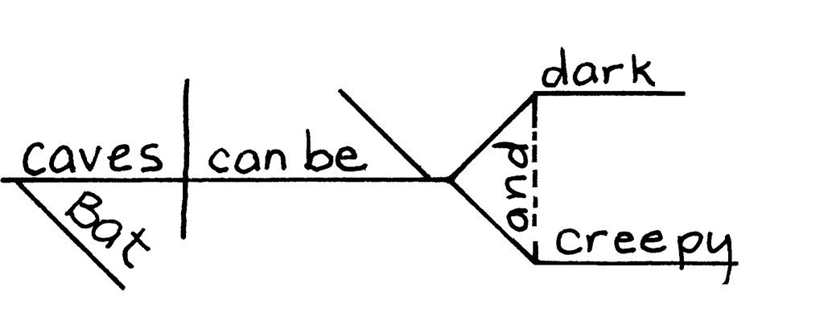

**3. 介词短语作表语形容词：**当介词短语用作表语形容词时，整个短语置于系动词之后，并位于指向主语的斜线之后。任何修饰语都置于其修饰的词语下方的斜线上，但仍位于句首，而不是句子的水平线下方。

**3. Prepositional phrases as predicate adjectives:** When a prepositional phrase is used as a predicate adjective, the entire phrase is placed on a pedestal following the linking verb and the slanted line pointing back to the subject. Any modifiers are put on slanted lines beneath the word or words they modify, but still on the pedestal, not underneath the sentence’s horizontal line.

服务员身穿精致的绿色制服。

The waiters are in elaborate green uniforms.

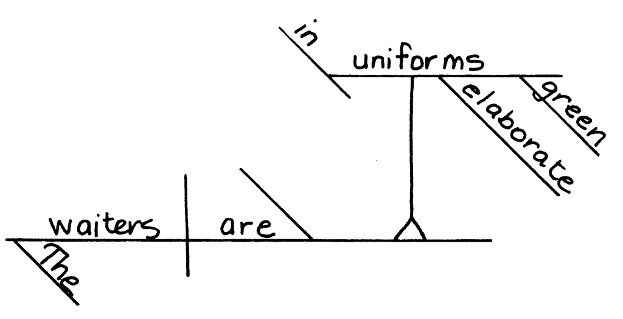

VB. 表语名词

VB. Predicate nominatives

**1. 表语：**表语的表示方法是将其放在系动词后面的水平线上。在动词和表语之间画一条斜线，指向主语，以此来表示表语的功能（重新命名主语的词）。

**1. Predicate nominatives:** A predicate nominative is diagrammed by placing it on the horizontal line after the linking verb. Between the verb and the predicate nominative, a slanted line is drawn, pointing back to the subject and demonstrating the function of the predicate nominative (a word renaming the subject).

我 是一颗浆果。

I am a berry.

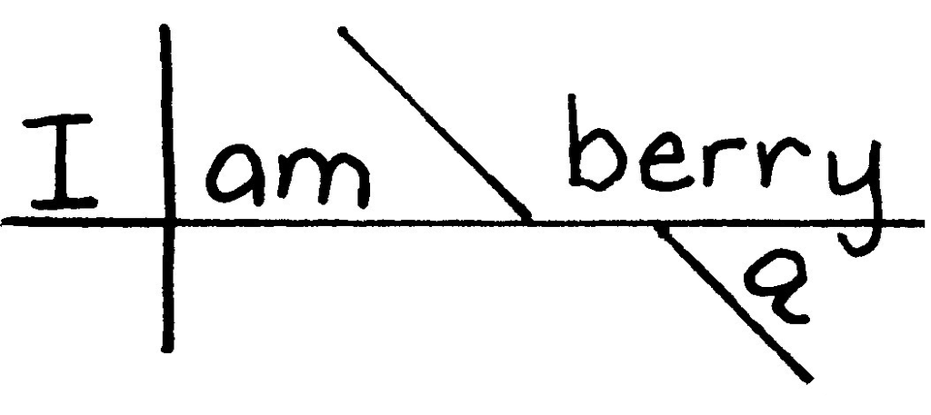

这种体型娇小、色彩斑斓的蜂鸟 强壮 而精力充沛。

The tiny, jewel-colored hummingbird is strong and frantically energetic.

[figure not shown]

**3. 不定式作表语：**不定式作表语的句型图解是将其置于主谓线上的一个基座上，但位于指向主语的斜线之后。所有修饰语都写在它们所修饰的词或词组下方的斜线上，但仍在基座上，而不是在句子的主水平线上。

**3. Infinitives as predicate nominatives:** An infinitive predicate nominative is diagrammed by placing it on a pedestal on the main subject-predicate line, but after the slanted line pointing to the subject. All modifiers are written on slanted lines under the word or words they modify, but still on the pedestal, not on the main horizontal line of the sentence.

存在 即 改变。

To exist is to change.

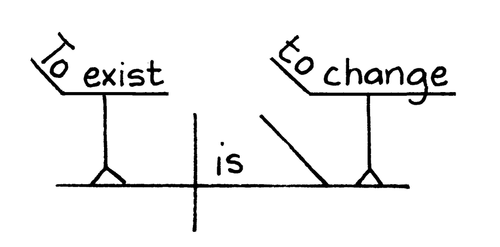

第六部分：短语和从句

PART VI: PHRASES AND CLAUSES

**我们已经讲解过介词短语，但还有其他几种类型的短语和从句也可以作为句子的重要组成部分。本节将展示它们的图示。**

**We have already covered prepositional phrases, but there are several other types of phrases and clauses that can function as essential parts of the sentence. Their diagrams are demonstrated in this section.**

经。短语

VIA. Phrases

**1. 动词短语：**动词短语包含句子的主要动词及其所有助动词。绘制动词短语图时，所有助动词都放在水平线上，紧挨着主要动词。

**1. Verb Phrases:** A verb phrase includes the main verb of the sentence and all of its helping verbs. When diagramming a verb phrase, all of the helping verbs are placed next to the main verb on the horizontal line.

到那时，他们 就会吸取教训<sup>了</sup>。

By that time, they will have learned their lesson.*

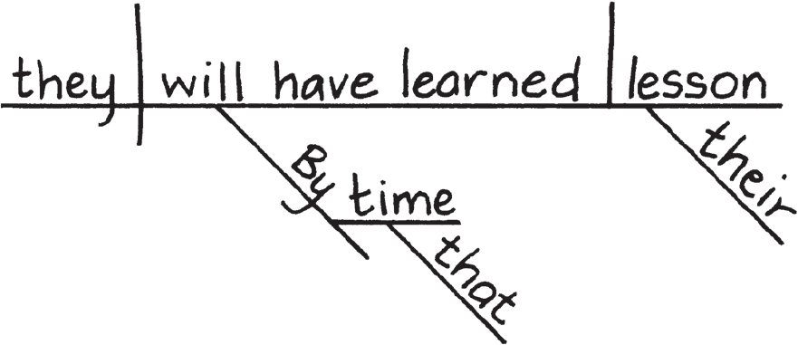

**2. 动名词、分词和不定式短语作直接宾语：**动名词（现在分词作名词）、分词或不定式及其所有相关词语构成动名词短语、分词短语或不定式短语。短语的结构图根据其在句子中的功能而定。当它作直接宾语时，置于直接宾语线之后。整个短语被置于一个凸起的基座上，以表明它是一个短语，而非典型的直接宾语。动名词、分词或不定式短语可能包含其自身的宾语和修饰语，这些宾语和修饰语也包含在基座上，并按其在相应位置进行结构图绘制。

**2. Gerund, participle, and infinitive phrases as direct objects:** A gerund (present participle acting as a noun), participle, or infinitive and all of the words that go with it form a gerund phrase, participle phrase, or infinitive phrase. The phrase is diagrammed according to its function in the sentence. When it is acting as the direct object, it is placed after the direct object line. The entire phrase is elevated on a pedestal to demonstrate that it is a phrase and not a typical direct object. The gerund, participle, or infinitive phrase may contain its own objects and modifiers, and they are included on the pedestal as well, diagrammed in their appropriate spots.

我 喜欢 吃淋着枫糖浆的煎饼、涂着巧克力糖霜的黄蛋糕和烤肋眼牛排。

I love eating pancakes with maple syrup, yellow cake with chocolate frosting, and grilled ribeye steaks.

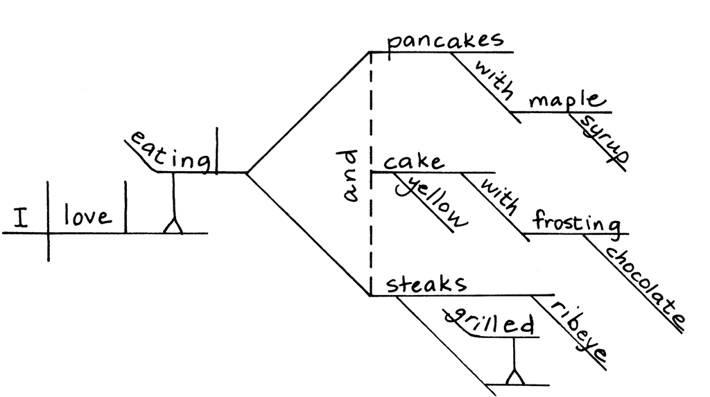

**3. 动名词和不定式短语作主语：**当动名词或不定式短语作句子的主语时，应将其放在主语行。整个短语会被置于一个凸起的位置，以表明它是一个短语，而非典型的主语。动名词或不定式短语可以包含宾语和修饰语，这些成分也应置于凸起的位置，并按其结构进行图示。

**3. Gerund and infinitive phrases as subjects:** When a gerund or infinitive phrase is acting as the subject of the sentence, it is placed on the subject line. The entire phrase is elevated on a pedestal to demonstrate that it is a phrase and not a typical subject. The gerund or infinitive phrase may contain its own objects and modifiers, and they are included on the pedestal as well, diagrammed in their appropriate spots.

当时人们还不知道用煤气 照明。†

Lighting by means of gas was yet unknown.†

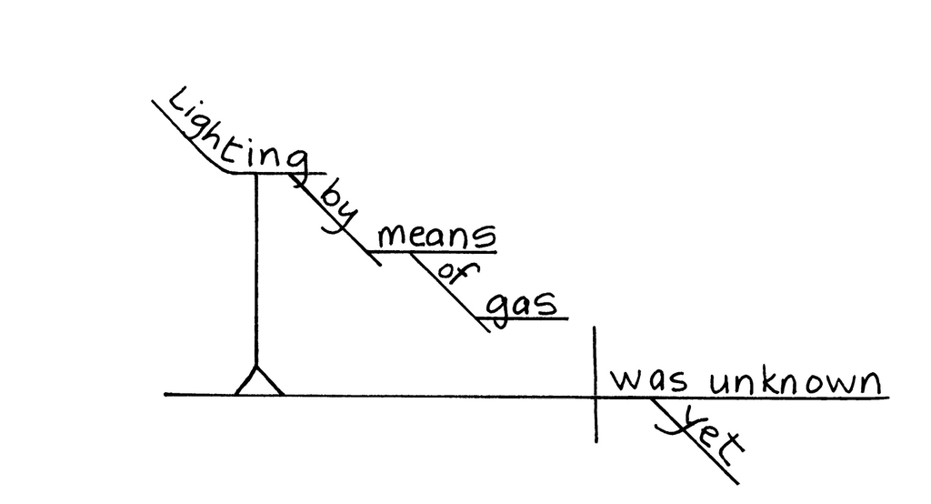

**4. 动名词和不定式短语作表语：**动名词或不定式短语可以作句子的表语。在这种情况下，它被画在系动词之后，并用斜线将动词与表语分隔开来。整个短语被置于一个凸起的基座上，以表明它是一个动词短语，而不是典型的表语。动名词或不定式短语可以包含自己的宾语和修饰语，它们也被画在基座上，并放置在相应的位置。

**4. Gerund and infinitive phrases as predicate nominatives:** A gerund or infinitive phrase may act as the predicate nominative of the sentence. In this case, it is diagrammed after the linking verb and the slanted line dividing the verb from the predicate nominative. The entire phrase is elevated on a pedestal to demonstrate that it is a verbal phrase and not a typical predicate nominative. The gerund or infinitive phrase may contain its own objects and modifiers, and they are included on the pedestal as well, diagrammed in their appropriate spots.

我 得 等武器和盔甲来支援<sup>我</sup>。

I was to wait for arms and armor to aid me.‡

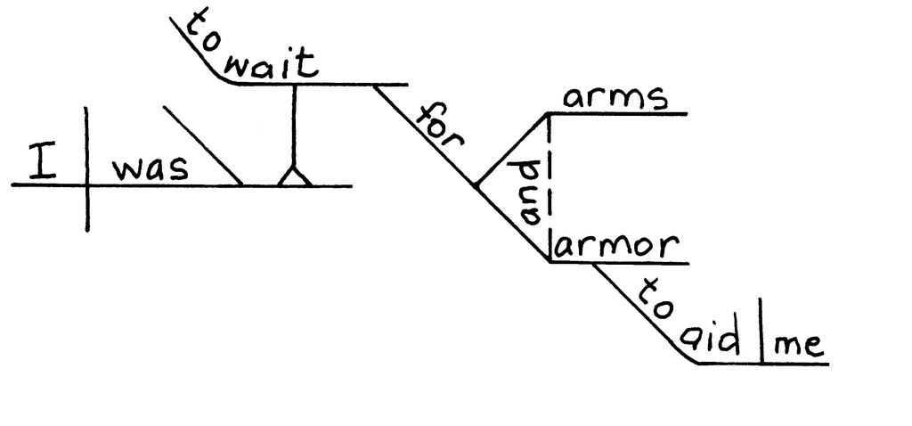

**5. 分词和不定式短语作表语形容词：**作表语形容词的短语在系动词和分隔动词与表语形容词的斜线之后进行图示。整个短语被置于基座上，以表明它是一个短语，而不是典型的主语补语。该短语可能包含其自身的宾语和修饰语，它们也包含在基座上，并在相应的位置进行图示。

**5. Participle and infinitive phrases as predicate adjectives:** Phrases serving as predicate adjectives are diagrammed after the linking verb and the slanted line dividing the verb from the predicate adjective. The entire phrase is elevated on a pedestal to demonstrate that it is a phrase and not a typical subject complement. The phrase may contain its own objects and modifiers, and they are included on the pedestal as well, diagrammed in their appropriate spots.

他们难道不心碎<sup>吗</sup>？

Were they not broken of heart?<sup>§</sup>

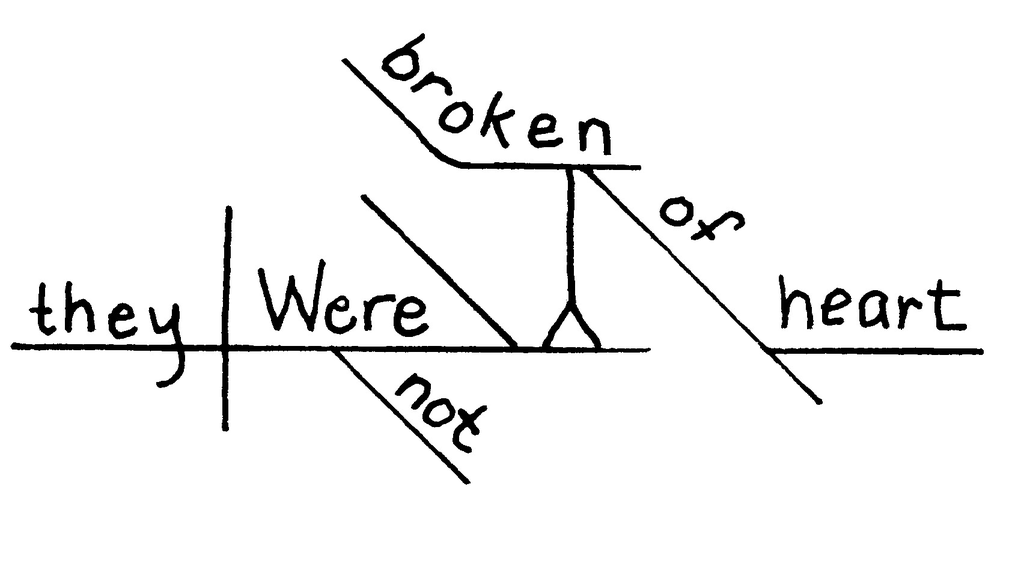

VIB. 独立分句

VIB. Independent clauses

**1. 多个独立分句：**当一个句子包含多个独立分句时，这些分句用单独的水平线表示，并用虚线连接分句的谓语。连接分句的连词位于虚线的中间，如果没有连词，则在连词上标记*“x” 。*

**1. Multiple independent clauses:** When a sentence contains more than one independent clause, the clauses are diagrammed on separate horizontal lines and are joined by a dotted line connecting the predicates of the clauses. A shelf for the conjunction joining the clauses is placed in the middle of the dotted line, and if there is no conjunction, an *x* is placed on the shelf.

柯林斯先生 为人并不和善；与他交往 令人厌烦，他对她的<sup>感情</sup>一定是虚构的。

Mr. Collins was not agreeable; his society was irksome, and his attachment to her must be imaginary.<sup>¶</sup>

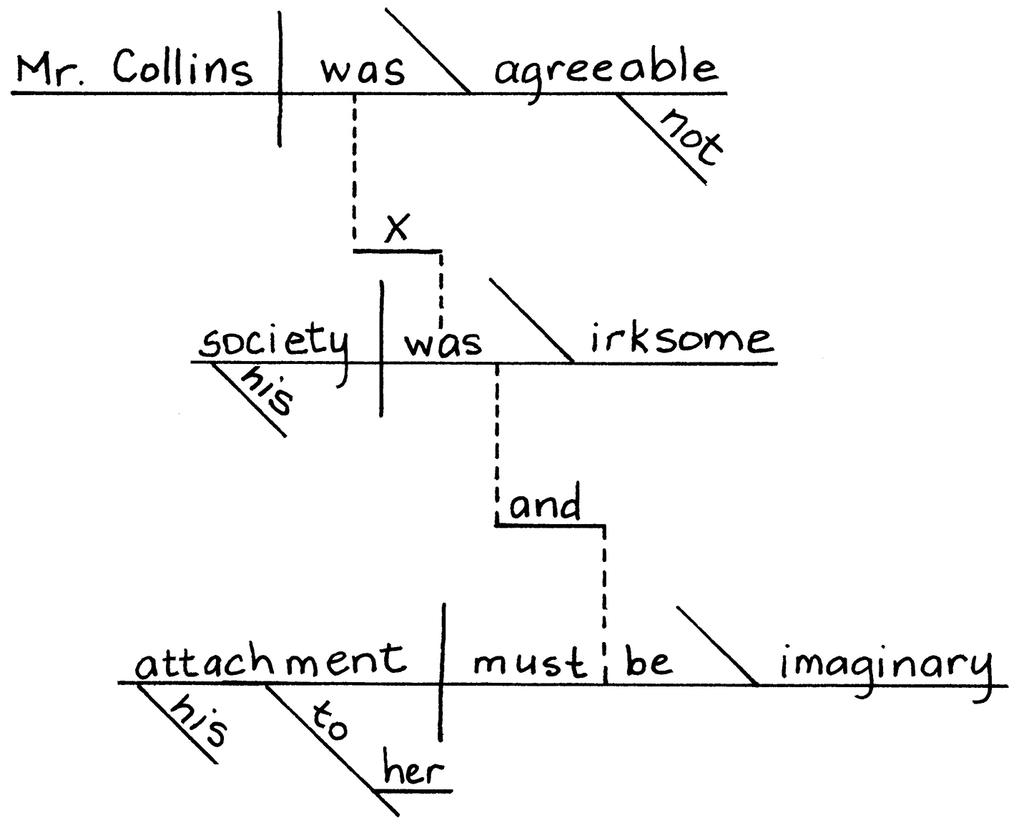

VIIC. 从属子句

VIIC. Dependent clauses

**1. 作形容词的从句：**当从句作形容词从句时，首先绘制包含它的主句的结构图。然后，将形容词从句放在主句下方，并用虚线连接主句中的名词或代词和修饰它的形容词从句。如果使用了关系代词，则虚线连接关系代词和被修饰的名词或代词。如果使用了关系副词，则虚线连接关系副词和它修饰的名词或代词。

**1. Dependent clauses acting as adjectives:** When a dependent clause is an adjective clause, the independent clause containing it is diagrammed first. Then, the adjective clause is placed underneath the independent clause, and a dotted line is used to connect the noun or pronoun in the independent clause to the adjective clause that is modifying it. If a relative pronoun is being used, the dotted line connects the relative pronoun to the noun or pronoun being modified. If a relative adverb is being used, the dotted line connects the relative adverb to the noun or pronoun it is modifying.

关系形容词示例：

Relative adjective example:

我， 一个 与你交谈的 人，曾目睹过许多罪恶。

I who speak to you have seen many evils.

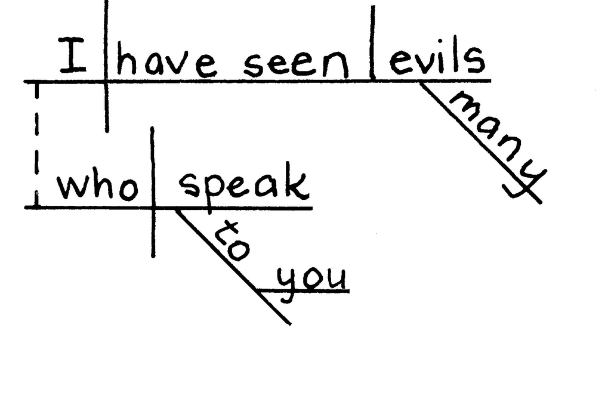

关系副词示例：

Relative adverb example:

大海是一片绿色的牧场，我们 的子孙后代将来会去那里觅食。<sup>#</sup>

The sea is a green pasture where our children’s grand-children will go for bread.<sup>#</sup>

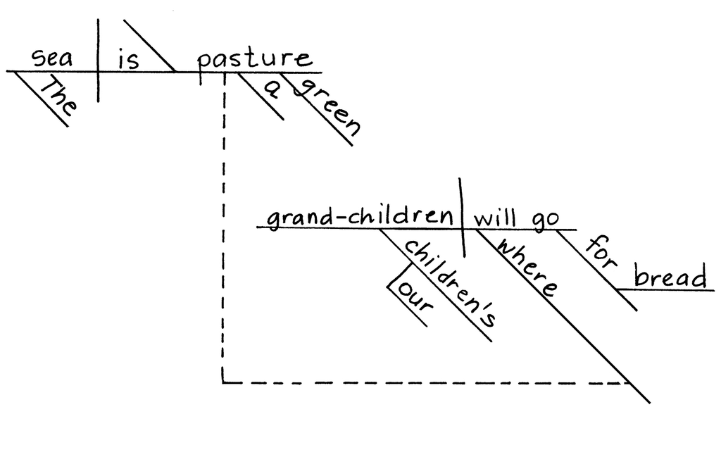

**2. 作状语的从句：**当从句是状语从句时，首先绘制包含它的主句的结构图。然后，将状语从句放在主句下方，并用虚线将状语从句与其修饰的词连接起来。虚线从被状语从句修饰的动词、形容词或副词开始，到状语从句自身的动词结束。

**2.Dependent clauses acting as adverbs:** When a dependent clause is an adverb clause, the independent clause containing it is diagrammed first. Then, the adverb clause is placed underneath the independent clause, and a dotted line is used to connect the the adverb clause to the word that it modifies. The dotted line begins at the verb, adjective, or adverb being modified by the adverb clause, and ends at the verb in the adverb clause itself.

晚宴 结束后，国王表达了一个愿望。

When the supper was finished, the king expressed a wish.

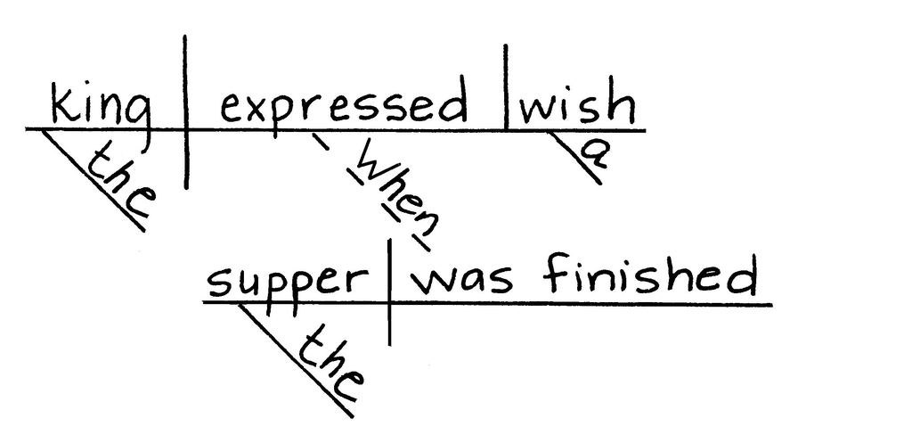

**3. 充当名词的从句：**名词性从句在句子中可以起到名词的任何作用。它可以是主语、直接宾语、间接宾语、表语或介词宾语。在绘制名词性从句的结构图时，会将其放置在基座上，以表明它并非附加于谓语的单个词句成分。如果从句包含自身的修饰语和宾语，则应将它们放置在基座上的相应位置。

**3. Dependent clauses acting as nouns:** A noun clause can have any function in a sentence that a noun would have. It can be a subject, direct object, indirect object, predicate nominative, or object of the preposition. When a noun clause is diagrammed, it is placed on a pedestal to demonstrate that it is not a one-word sentence element attached to the clause’s predicate. If the clause contains its own modifiers and objects, those are placed in the appropriate spots on the pedestal.

**名词性从句作主语**：

**Noun clause as subject**:

抓住 他的 东西发出了哼哼声<sup>。</sup>

Whatever had seized him made snorting noises.**

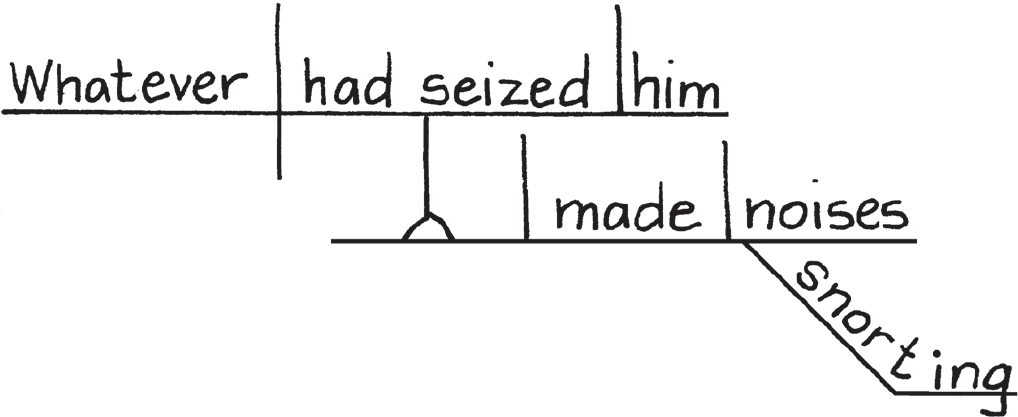

**名词性从句作直接宾语：**

**Noun clause as direct object:**

我 知道 你丢失的钥匙在哪里。

I know where your lost keys are.

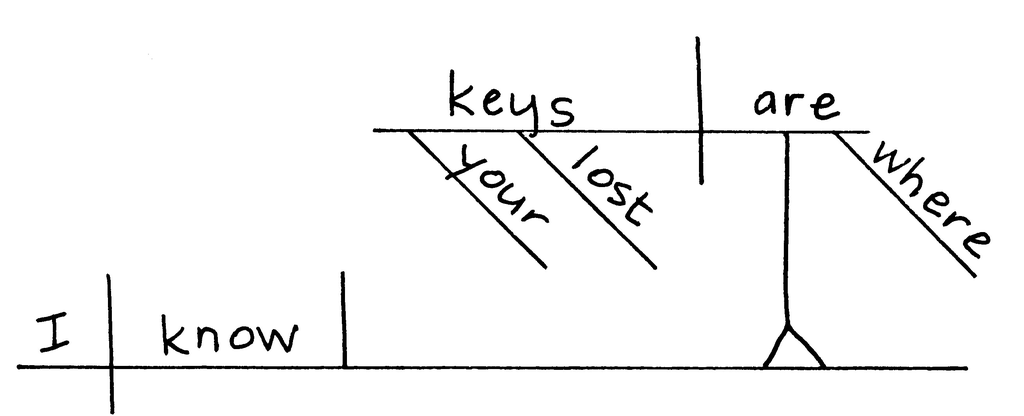

**名词性从句作表语：**

**Noun clause as predicate nominative:**

放风筝最棒的地方 在于 它 给母亲带来 的快乐。††

What was best about flying any of the kites was what it did for Mother.††

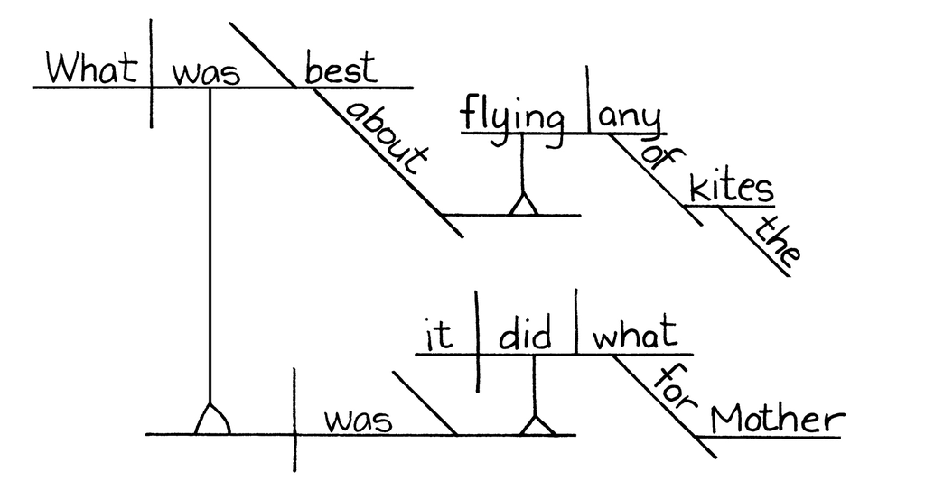

**名词从句作介词宾语：**如果*that*作从属词而不是指示代词，则应将其放在谓语上方的水平线上，并用虚线垂直线与谓语连接。

**Noun clause as object of the preposition:** If *that* is acting as a subordinating word, rather than as a demonstrative pronoun, it should be placed on a horizontal line above the predicate, connected to the predicate with a dotted vertical line.

我 之前写过我们这里受大气环境影响有多大，而且我觉得就我个人而言，这个问题 最近变得越来越严重了<sup>。</sup>

I have previously written about how much we are affected by atmospheres here, and I think that in my own case this trouble is getting much worse lately.‡‡

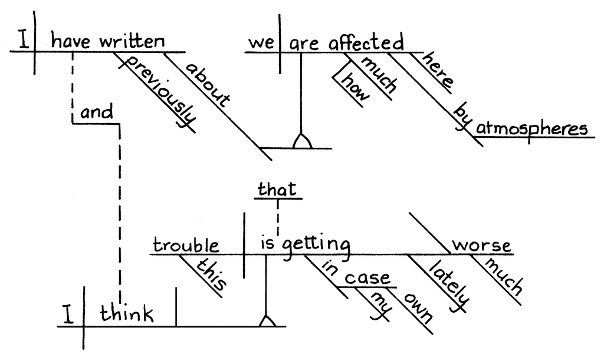

**名词从句作同位语：**当一个从属名词从句作同位语时，整个名词从句放在同位语空间的树状结构中，用括号括起来。

**Noun clause as appositive:** When a dependent noun clause acts as an appositive, the entire noun clause is placed on a tree in the appositive space, between parentheses.

文章认为学习语法对大脑有益，但这种观点并没有说服我。

The article’s argument, that studying grammar is good for your brain, didn’t convince me.

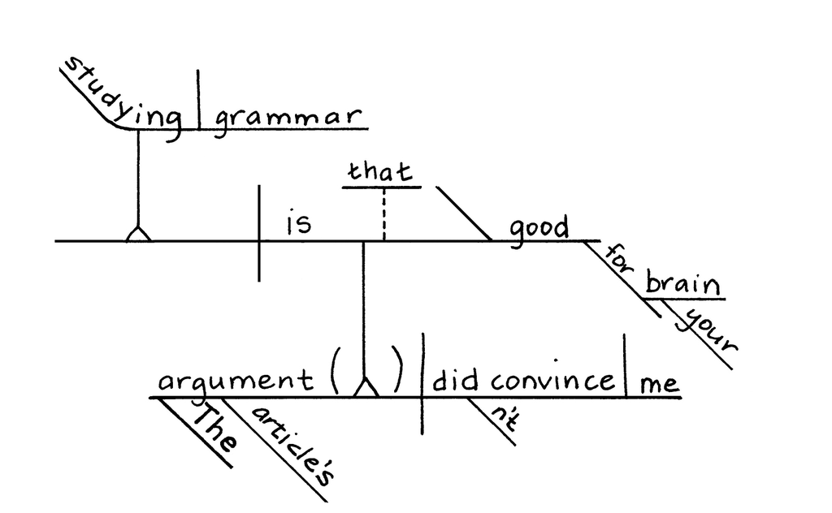

*摘自乔治·麦克唐纳的*《光之公主及其他童话故事》*

* from *The Light Princess and Other Fairy Stories* by George MacDonald

†摘自H.E.麦康伯所著《*伟大发明家的故事》*

† from *Stories of Great Inventors* by H.E. Macomber

‡摘自霍华德·派尔所著*《圆桌骑士的故事》*

‡ from *The Story of the Champions of the Round Table* by Howard Pyle

摘自霍华德·派尔所著*《圆桌骑士的故事*》

§ from *The Story of the Champions of the Round Table* by Howard Pyle

摘自简·奥斯汀的*《傲慢与偏见*》

¶ from *Pride and Prejudice* by Jane Austen

出自赫尔曼·梅尔维尔的*《白鲸*》

# from *Moby Dick*, by Herman Melville

**摘自劳埃德·亚历山大的《*三之书》*

** from *The Book of Three* by Lloyd Alexander

††改编自劳伦斯·叶普的*《龙翼》*

†† adapted from *Dragonwings* by Laurence Yep

‡‡摘自安妮·弗兰克的*《安妮日记》，*由BM Mooyart从荷兰语翻译。

‡‡ from Anne Frank’s *The Diary of a Young Girl* translated from the Dutch by B.M. Mooyart

第七部分：填满角落

PART VII: FILLING UP THE CORNERS

**1. 插入语：**当插入语与句子在语法上没有任何联系时，将其图示在句子旁边或下方，以表明它属于句子，但与句子没有语法联系。

**1. Parenthetical elements:** When a parenthetical element is not connected to the sentence in any grammatical way, it is diagrammed off to the side or underneath the sentence, to show that it belongs to the sentence but has no grammatical connection to the sentence.

我们今天 见到了新邻居，他们，我们 我觉得他们是非常和蔼可亲的人。

We met the new neighbors today, who, we think, are very pleasant people.

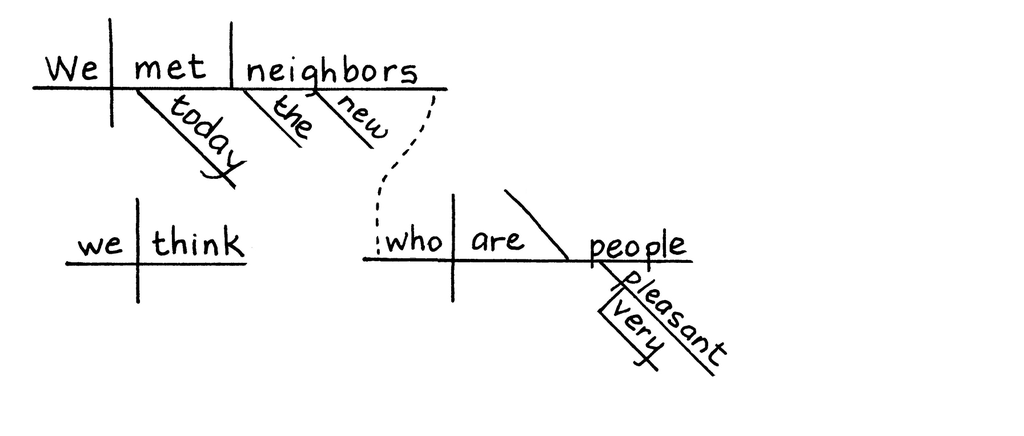

难以置信吧？火车竟然准点到达了（这可是难得一见的好事）。

The train—can you believe it?—was on time (a rare and happy occurrence).

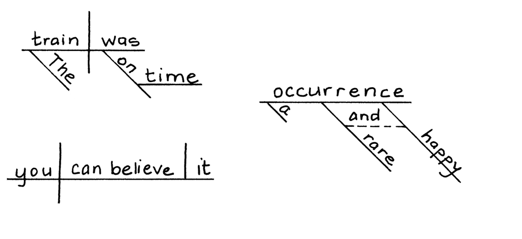

**2. 直接称呼名词：**直接称呼名词指代说话对象（人或物）。它在图示上方单独一行标出，以表明其与句子本身没有语法联系。

**2. Noun of direct address:** A noun of direct address names a person or thing who is being spoken to. It is diagrammed on a separate line above the diagram to demonstrate its lack of grammatical connection to the sentence.

朋友们，罗马人，同胞们，请听我说！

Friends, Romans, countrymen, lend me your ears!

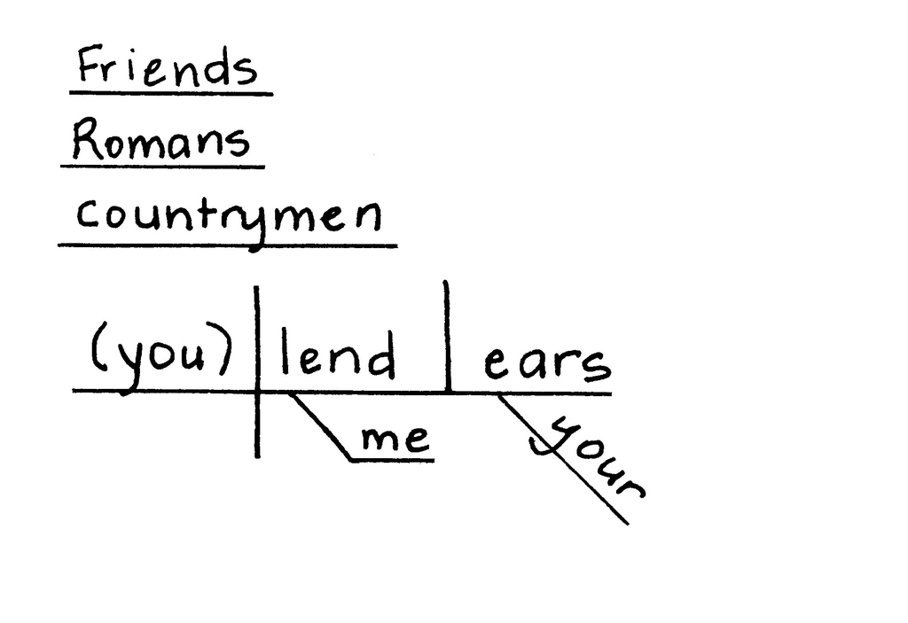

**3. 感叹词：**感叹词用一条自由的线表示在句子上方，以表明它与句子没有明显的语法联系。

**3. Interjection:** An interjection is diagrammed on a free-floating line above the sentence, to show that it does not have a clear grammatical connection to the sentence.

呼！真是 好险。

Whew! That was a close one.

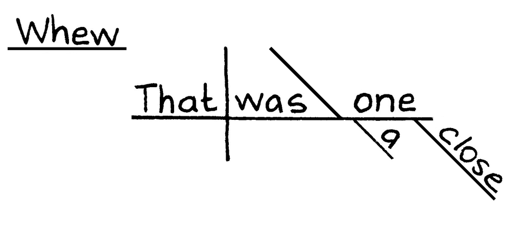

**4. 短语作同位语：**当一个短语作同位语时，只有同位语名词放在它所修饰或解释的词之后，并用括号括起来。任何修饰语都放在同位语名词下方。

**4. Phrases as appositives:** When a phrase acts as an appositive, only the appositive noun is placed in parentheses after the word it renames or explains. Any modifiers are placed beneath the appositive noun.

1857年，中国锡矿工人 建立了马来西亚城市吉隆坡，即金三角。

Chinese tin miners founded the Malaysian city Kuala Lumpur, the Golden Triangle, in 1857.

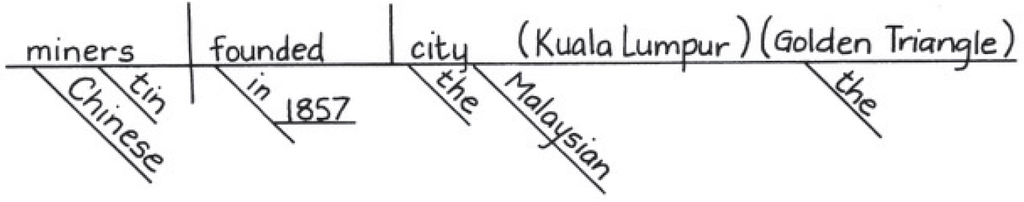

**5. 独立结构：**独立结构与句子语义关系密切，但语法上并无关联。与插入语类似，独立结构的图解也与主句分开。独立结构的图解通常位于句子上方，以表明其对句子的重要性高于插入语。

**5. Absolute constructions:** An absolute construction has a strong semantic relationship to the sentence, but no grammatical relationship to it. Like parenthetical elements, absolute constructions are diagrammed separately from the main sentence. Absolute constructions are diagrammed above the sentence to demonstrate that they are more important to the sentence than a parenthetical element is.

鲍尔斯坦博士 依然待在一旁，他那张严肃的、蓄着胡须的脸依旧没有<sup>变化</sup>。

Dr. Bauerstein remained in the background, his grave bearded face unchanged.*

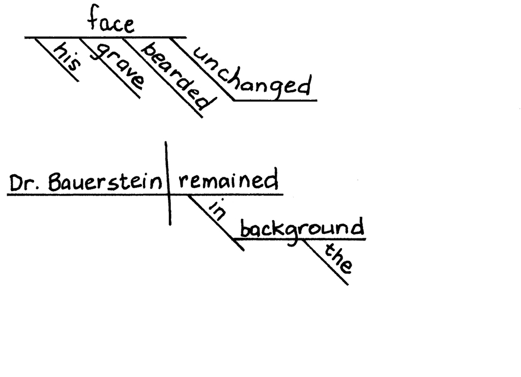

*摘自阿加莎·克里斯蒂的*《斯泰尔斯庄园奇案》*

* from *The Mysterious Affair at Styles* by Agatha Christie

指数

INDEX

所列页码与本书印刷版一致。您可以使用设备的搜索功能在文本中查找特定词语。

Page numbers listed correspond to the print edition of this book. You can use your device’s search function to locate particular terms in the text.

一个

A

绝对结构，53

absolute constructions, 53

形容词从句，44

adjective clauses, 44

形容词

adjectives

文章如，14

articles as, 14

化合物，13，14

compound, 13, 14

指示代词，例如，15

demonstrative pronouns as, 15

从属子句，例如，44

dependent clauses as, 44

描述性的，13

descriptive, 13

不定代词，例如，15

indefinite pronouns as, 15

疑问代词，例如，15

interrogative pronouns as, 15

过去分词 as，16

past participles as, 16

所有格代词，例如，14

possessive pronouns as, 14

介词短语，例如，21

prepositional phrases as, 21

现在分词形式为，16

present participles as, 16

状语从句，45

adverb clauses, 45

副词

adverbs

肯定，18

of affirmation, 18

化合物，18

compound, 18

从属子句，例如，45

dependent clauses as, 45

疑问代词，例如，18

interrogative pronouns as, 18

修饰形容词，17

modifying adjectives, 17

修饰其他副词，17

modifying other adverbs, 17

修饰动词，17

modifying verbs, 17

否定，19

of negation, 19

介词短语，例如，22

prepositional phrases as, 22

同位语名词，53

appositive nouns, 53

直接宾语之后，31

after direct objects, 31

受试者之后，8

after subjects, 8

同位语

appositives

名词性从句，例如，49

noun clauses as, 49

例如，53

phrases as, 53

冠词，作形容词，14

articles, as adjectives, 14

C

C

第 32 至 49 条，*另请参阅特定类型的条款*

clauses 32–49, *See also specific types of clauses*

命令，1

commands, 1

普通名词，1

common nouns, 1

复合形容词，13，14

compound adjectives, 13, 14

复合副词，18

compound adverbs, 18

复合直接宾语，27–28

compound direct objects, 27–28

复合间接宾语，32

compound indirect objects, 32

复合名词

compound nouns

作为直接宾语，30

as direct objects, 30

作为研究对象，2

as subjects, 2

复合表语形容词，35

compound predicate adjectives, 35

复合谓语主格，37

compound predicate nominatives, 37

复合谓语，9

compound predicates, 9

准协调者加入，11

quasi-coordinators joining, 11

含复合直接宾语，28

with compound direct objects, 28

包含多个并列连词，10

with multiple coordinating conjunctions, 10

与同一个直接宾语相同，28

with the same direct object, 28

复合主题，3–4，8

compound subjects, 3–4, 8

连词

conjunctions

在复合形容词中，14

in compound adjectives, 14

在复合间接宾语中，32

in compound indirect objects, 32

在复合谓语中，9-10

in compound predicates, 9–10

在介词的复合宾语中，25

in compound objects of prepositions, 25

在复合表语形容词中，35

in compound predicate adjectives, 35

在复合谓语主格中，37

in compound predicate nominatives, 37

在复合受试者中，3

in compound subjects, 3

连接两个副词，18

linking two adverbs, 18

收缩

contractions

作为谓词，10

as predicates, 10

作为研究对象，6

as subjects, 6

并列连词

coordinating conjunctions

在复合谓语中，10

in compound predicates, 10

在复合受试者中，3-4

in compound subjects, 3–4

并列相关连词，8

coordinating correlative conjunctions, 8

D

D

指示代词

demonstrative pronouns

作为形容词，15

as adjectives, 15

作为直接宾语，29

as direct objects, 29

作为研究对象，6

as subjects, 6

从属子句

dependent clauses

作为形容词，44

as adjectives, 44

作为副词，45

as adverbs, 45

作为名词，46

as nouns, 46

描述性形容词，13

descriptive adjectives, 13

直接宾语，27

direct objects, 27

同位语名词在之后，31

appositive nouns after, 31

化合物，27–28

compound, 27–28

复合名词，例如，30

compound nouns as, 30

指示代词，例如，29

demonstrative pronouns as, 29

动名词，例如，29

gerunds as, 29

不定式如，30

infinitives as, 30

疑问代词，例如，29

interrogative pronouns as, 29

以及宾语补语，31–32

and object complements, 31–32

介词短语，例如，23

prepositional phrases as, 23

专有名词，例如，30

proper names as, 30

明白了，31

understood, 31

E

E

省略号，8

ellipsis, 8

G

G

动名词短语，40

gerund phrases, 40

作为直接宾语，40

as direct objects, 40

作为表语名词，42

as predicate nominatives, 42

作为研究对象，41

as subjects, 41

动名词

gerunds

作为直接宾语，29

as direct objects, 29

作为介词宾语，25

as objects of prepositions, 25

作为研究对象，7

as subjects, 7

H

H

助动词，9、11、39

helping verbs, 9, 11, 39

劝诫动词，8

hortative verbs, 8

我

I

祈使句，1

imperative sentences, 1

不定代词

indefinite pronouns

作为形容词，15

as adjectives, 15

作为研究对象，5

as subjects, 5

独立分句，43

independent clauses, 43

间接宾语，32

indirect objects, 32

化合物，32

compound, 32

专有名词，例如，33

proper nouns as, 33

不定式短语，40

infinitive phrases, 40

作为表语形容词，42

as predicate adjectives, 42

作为表语名词，42

as predicate nominatives, 42

作为研究对象，41

as subjects, 41

不定式

infinitives

作为直接宾语，30

as direct objects, 30

作为表语名词，37

as predicate nominatives, 37

作为研究对象，7

as subjects, 7

强调代词，7

intensive pronouns, 7

感叹词，52

interjections, 52

疑问代词

interrogative pronouns

作为形容词，15

as adjectives, 15

作为副词，18

as adverbs, 18

作为直接宾语，29

as direct objects, 29

作为研究对象，6

as subjects, 6

N

N

名词性从句，46

noun clauses, 46

作为同位语，49

as appositives, 49

作为直接宾语，46

as direct objects, 46

作为介词宾语，48

as object of prepositions, 48

作为表语名词，47

as predicate nominatives, 47

作为研究对象，46

as subjects, 46

名词

nouns

同位语 8、31、53

appositive 8, 31, 53

普通，1

common, 1

化合物，2，30

compound, 2, 30

从属子句，例如，46

dependent clauses as, 46

直接地址，52

of direct address, 52

宾语补语，31

object complement, 31

介词短语，例如，23–24

prepositional phrases as, 23–24

正确，4，33

proper, 4, 33

哦

O

宾语补语，31–32

object complements, 31–32

对象

objects

直接，23，27–32，46

direct, 23, 27–32, 46

间接，32–33，46

indirect, 32–33, 46

介词，24–25

of prepositions, 24–25

P

P

括号内的内容，51–53

parenthetical elements, 51–53

分词短语，40，42

participle phrases, 40, 42

过去分词作形容词，16

past participles, as adjectives, 16

人称代词，2

personal pronouns, 2

短语 39–42，*另请参阅特定类型的短语*

phrases 39–42, *See also specific types of phrases*

所有格代词，14

possessive pronouns, 14

表语形容词，35

predicate adjectives, 35

化合物，35

compound, 35

不定式短语，例如，42

infinitive phrases as, 42

分词短语，例如，42

participle phrases as, 42

介词短语如，21，36

prepositional phrases as, 21, 36

表语名词，36

predicate nominatives, 36

化合物，37

compound, 37

动名词短语，例如，42

gerund phrases as, 42

不定式，37

infinitive, 37

不定式短语，例如，42

infinitive phrases as, 42

名词性从句，例如，47

noun clauses as, 47

介词短语，例如，24

prepositional phrases as, 24

谓词

predicates

化合物，9–10，11，28

compound, 9–10, 11, 28

简单，9-11

simple, 9–11

介词短语

prepositional phrases

作为形容词，21

as adjectives, 21

作为副词，22

as adverbs, 22

作为直接宾语，23

as direct objects, 23

修饰其他介词短语，22

modifying other prepositional phrases, 22

作为名词，23–24

as nouns, 23–24

作为介词宾语，24

as objects of the preposition, 24

作为表语形容词，21，36

as predicate adjectives, 21, 36

作为表语名词，24

as predicate nominatives, 24

作为受试者，5，23

as subjects, 5, 23

介词，宾语，21，24-25，48

prepositions, objects of, 21, 24–25, 48

现在分词作形容词，16

present participles, as adjectives, 16

代词

pronouns

指示性的，6，15，29

demonstrative, 6, 15, 29

不确定，5，15

indefinite, 5, 15

强化，7

intensive, 7

疑问句，6，15，18，29

interrogative, 6, 15, 18, 29

个人，2

personal, 2

所有格，14

possessive, 14

亲属，31，44

relative, 31, 44

作为受试者，2、5、6

as subjects, 2, 5, 6

理解的相对，31

understood relative, 31

专有名词作直接宾语，30

proper names, as direct objects, 30

专有名词

proper nouns

作为间接宾语，33

as indirect objects, 33

作为研究对象，4

as subjects, 4

问

Q

准协调器，11

quasi-coordinators, 11

拉

R

关系形容词，44

relative adjectives, 44

关系副词，44

relative adverbs, 44

关系代词，31，44

relative pronouns, 31, 44

S

S

简单谓词，9-11

simple predicates, 9–11

简单科目，1-8。*另见*“科目” 。

simple subjects, 1–8. *See also* subjects

主题

subjects

同位语名词，例如，8

appositive nouns as, 8

普通名词，1

common nouns, 1

复合名词，例如，2

compound nouns as, 2

收缩如，6

contractions as, 6

指示代词，例如，6

demonstrative pronouns as, 6

动名词短语，例如，41

gerund phrases as, 41

动名词，例如，7

gerunds as, 7

不定代词，例如，5

indefinite pronouns as, 5

不定式短语，例如，41

infinitive phrases as, 41

不定式如，7

infinitives as, 7

强调代词，7

intensive pronouns with, 7

疑问代词，例如，6

interrogative pronouns as, 6

介词短语，例如，5，23

prepositional phrases as, 5, 23

代词如，2

pronouns as, 2

专有名词，例如，4

proper nouns as, 4

简单，1

simple, 1

明白了，1

understood you, 1

未知，8

unknown, 8

U

U

理解

understood

直接宾语，31

direct object, 31

助动词，11

helping verb, 11

关系代词，31

relative pronoun, 31

你，1

you, 1

未知受试者，8

unknown subjects, 8

V

V

动词短语，39

verb phrases, 39

动词

verbs

帮助，9，39

helping, 9, 39

劝诫，8

hortative, 8

理解帮助，11

understood helping, 11

**在线古典教育**

**Online Classical Education**

*出自《训练有素的心灵》*的创作团队之手

From the creators of *The Well-Trained Mind*

[figure not shown]

**提供初中和高中所有科目的在线直播教学：**

**Providing live, online instruction in all middle school and high school subjects:**

语法

Grammar

数学

Mathematics

说明文与创意写作

Expository & Creative Writing

修辞

Rhetoric

文学

Literature

历史

History

外语

Foreign Languages

自然科学

Natural Sciences

SAT备考及学习技巧

SAT Preparation & Study Skills

**还有更多！**

**And more!**

**www.wtmacademy.com**

**www.wtmacademy.com**

（844）986-9862

(844) 986-9862

版权所有 © 2019 Well-Trained Mind Press

Copyright 2019 Well-Trained Mind Press

**复印和分发政策**  
请勿在电子邮件列表或网站上复制本材料的任何部分。

**Photocopying and Distribution Policy**  
Please do not reproduce any part of this material on e-mail lists or websites.

对于**家庭用户**：您可以根据自己家庭的需要，复印本书的任意份数。

For **families**: You may make as many photocopies from this book as you need for use WITHIN YOUR OWN FAMILY.

**学校和合作社**不得复印本书的任何部分。

**Schools and co-ops** MAY NOT PHOTOCOPY any portion of this book.

出版商出版物编目数据  
（由 Donahue Group, Inc. 编制）

Publisher’s Cataloging-In-Publication Data  
(Prepared by The Donahue Group, Inc.)

作者：杰西卡·奥托 | 苏珊·怀斯·鲍尔 | 帕蒂·雷布内（插画家）

Names: Otto, Jessica, author. | Bauer, Susan Wise, author. | Rebne, Patty, illustrator.

标题：图表词典 / 作者：Jessica Otto 和 Susan Wise Bauer；图表：Patty Rebne。

Title: The diagramming dictionary / by Jessica Otto and Susan Wise Bauer ; diagrams by Patty Rebne.

描述：[弗吉尼亚州查尔斯城]：Well-Trained Mind Press，[2019] | “面向年轻作家、有抱负的修辞学家以及任何需要了解如何分析英语句子结构的人的完整参考指南。” | 与“Well-Trained Mind 语法”系列配套编写。| 包含索引。 | 适用年龄：11岁及以上。 | 读者对象：初中和高中教师。

Description: [Charles City, Virginia] : Well-Trained Mind Press, [2019] | “A Complete Reference Guide for Young Writers, Aspiring Rhetoricians, and Anyone Else Who Needs to Understand How to Diagram English Sentences.” | Designed in conjunction with the Grammar for the Well-Trained Mind series. | Includes index. | Interest age level: 11 and up. | Audience: Middle and high school instructors.

标识符：ISBN 9781945841385 | ISBN 9781945841392（电子书）

Identifiers: ISBN 9781945841385 | ISBN 9781945841392 (ebook)

主题：LCSH：英语——语法——词典——少儿文学。| 英语——句子——词典——少儿文学。| 英语——修辞——词典——少儿文学。| CYAC：英语——语法——词典。| 英语——句子——词典。| 英语——修辞——词典。

Subjects: LCSH: English language--Grammar--Dictionaries--Juvenile literature. | English language--Sentences--Dictionaries--Juvenile literature. | English language--Rhetoric--Dictionaries--Juvenile literature. | CYAC: English language--Grammar--Dictionaries. | English language--Sentences--Dictionaries. | English language--Rhetoric--Dictionaries.

分类：LCC LB1631 .O88 2019（印刷版）| LCC LB1631（电子书）| DDC 428.00712--dc23

Classification: LCC LB1631 .O88 2019 (print) | LCC LB1631 (ebook) | DDC 428.00712--dc23

未经版权所有者事先书面许可，不得以任何形式或任何方式（包括电子或机械方式，例如复印或录音）复制或传播本作品的任何部分，也不得通过任何信息存储或检索系统进行复制或传播，除非联邦版权法明确允许此类复制，或者符合上述复印和分发政策。

No part of this work may be reproduced or transmitted in any form or by any means, electronic or mechanical, including photocopying or recording, or by any information storage or retrieval system without prior written permission of the copyright owner unless such copying is expressly permitted by federal copyright law or unless it complies with the Photocopying and Distribution Policy above.

如需查看更正列表，请访问www.welltrainedmind.com/corrections

For a list of corrections, please visit www.welltrainedmind.com/corrections

封面设计：Mike Fretto

Cover design by Mike Fretto